# Exploratory Data Analysis of Aadhaar Enrolment Data

## Problem Statement

Aadhaar enrolment data captures Enrolment patterns across different age groups over time. Understanding these patterns is crucial for identifying enrolment trends, enrolment participation, and potential accessibility gaps.

This study performs a structured Exploratory Data Analysis (EDA) on Aadhaar enrolment data to:

- Understand enrolment distribution across age groups
- Identify temporal trends
- Explore relationships between Enrolment groups
- Derive insights with potential administrative and social impact

# Importing api_data_aadhar_enrolment_0_500000.csv

```python
import warnings
warnings.filterwarnings('ignore')
import pandas as pd
import numpy as np
import matplotlib.pyplot as plt
df1 = pd.read_csv('/Users/karansingh/Desktop/Hackathon/DAtaHackathon/api_data_aadhar_enrolment_0_500000.csv')
```

## Dataset Overview

Understanding dataset structure, size, and column information.

```python
df1.head()
```

|  | date | state | district | pincode | age_0_5 | age_5_17 | age_18_greater |
| --- | --- | --- | --- | --- | --- | --- | --- |
| 0 | 02-03-2025 | Meghalaya | East Khasi Hills | 793121 | 11 | 61 | 37 |
| 1 | 09-03-2025 | Karnataka | Bengaluru Urban | 560043 | 14 | 33 | 39 |
| 2 | 09-03-2025 | Uttar Pradesh | Kanpur Nagar | 208001 | 29 | 82 | 12 |
| 3 | 09-03-2025 | Uttar Pradesh | Aligarh | 202133 | 62 | 29 | 15 |
| 4 | 09-03-2025 | Karnataka | Bengaluru Urban | 560016 | 14 | 16 | 21 |

```python
df1.info()
```

```
<class 'pandas.core.frame.DataFrame'>
RangeIndex: 500000 entries, 0 to 499999
Data columns (total 7 columns):
 #   Column          Non-Null Count   Dtype
---  ------          --------------   -----
 0   date            500000 non-null  object
 1   state           500000 non-null  object
 2   district        500000 non-null  object
 3   pincode         500000 non-null  int64
 4   age_0_5         500000 non-null  int64
 5   age_5_17        500000 non-null  int64
 6   age_18_greater  500000 non-null  int64
dtypes: int64(4), object(3)
memory usage: 26.7+ MB
```

```python
df1.shape
```

```
(500000, 7)
```

```python
df1.columns
```

```
Index(['date', 'state', 'district', 'pincode', 'age_0_5', 'age_5_17',
       'age_18_greater'],
      dtype='object')
```

```python
df1.dtypes
```

```
date              object
state             object
district          object
pincode            int64
age_0_5            int64
age_5_17           int64
age_18_greater     int64
dtype: object
```

```python
df1.describe()
```

|  | pincode | age_0_5 | age_5_17 | age_18_greater |
| --- | --- | --- | --- | --- |
| count | 500000.000000 | 500000.000000 | 500000.000000 | 500000.000000 |
| mean | 519204.051054 | 4.040812 | 2.315682 | 0.245558 |
| std | 206793.322085 | 24.417921 | 20.191196 | 4.438557 |
| min | 100000.000000 | 0.000000 | 0.000000 | 0.000000 |
| 25% | 362229.000000 | 1.000000 | 0.000000 | 0.000000 |
| 50% | 517131.000000 | 2.000000 | 0.000000 | 0.000000 |
| 75% | 712139.000000 | 3.000000 | 1.000000 | 0.000000 |
| max | 855456.000000 | 2688.000000 | 1812.000000 | 855.000000 |

```python
## check null value
df1['state'].isnull().sum()
```

```
np.int64(0)
```

```python
## check state column
df1['state'].nunique()
```

```
54
```

# Importing api_data_aadhar_enrolment_500000_1000000.csv

```python
df2 = pd.read_csv('/Users/karansingh/Desktop/Hackathon/DAtaHackathon/api_data_aadhar_enrolment_500000_1000000.csv')
```

## Dataset Overview

Understanding dataset structure, size, and column information.

```python
df2.head()
```

|  | date | state | district | pincode | age_0_5 | age_5_17 | age_18_greater |
| --- | --- | --- | --- | --- | --- | --- | --- |
| 0 | 26-10-2025 | Andhra Pradesh | Nalgonda | 508004 | 0 | 1 | 0 |
| 1 | 26-10-2025 | Andhra Pradesh | Nalgonda | 508238 | 1 | 0 | 0 |
| 2 | 26-10-2025 | Andhra Pradesh | Nalgonda | 508278 | 1 | 0 | 0 |
| 3 | 26-10-2025 | Andhra Pradesh | Nandyal | 518432 | 0 | 1 | 0 |
| 4 | 26-10-2025 | Andhra Pradesh | Nandyal | 518543 | 1 | 0 | 0 |

```python
df2.info()
```

```
<class 'pandas.core.frame.DataFrame'>
RangeIndex: 500000 entries, 0 to 499999
Data columns (total 7 columns):
 #   Column          Non-Null Count   Dtype
---  ------          --------------   -----
 0   date            500000 non-null  object
 1   state           500000 non-null  object
 2   district        500000 non-null  object
 3   pincode         500000 non-null  int64
 4   age_0_5         500000 non-null  int64
 5   age_5_17        500000 non-null  int64
 6   age_18_greater  500000 non-null  int64
dtypes: int64(4), object(3)
memory usage: 26.7+ MB
```

```python
# check shape
df2.shape
```

```
(500000, 7)
```

```python
# check columns
df2.columns
```

```
Index(['date', 'state', 'district', 'pincode', 'age_0_5', 'age_5_17',
       'age_18_greater'],
      dtype='object')
```

```python
df2.describe()
```

|  | pincode | age_0_5 | age_5_17 | age_18_greater |
| --- | --- | --- | --- | --- |
| count | 500000.000000 | 500000.000000 | 500000.000000 | 500000.000000 |
| mean | 518077.362504 | 3.009628 | 1.082962 | 0.089984 |
| std | 204615.861812 | 4.658289 | 2.537596 | 1.073745 |
| min | 100000.000000 | 0.000000 | 0.000000 | 0.000000 |
| 25% | 365541.000000 | 1.000000 | 0.000000 | 0.000000 |
| 50% | 517583.000000 | 2.000000 | 0.000000 | 0.000000 |
| 75% | 695023.000000 | 3.000000 | 1.000000 | 0.000000 |
| max | 855456.000000 | 210.000000 | 97.000000 | 318.000000 |

# Importing api_data_aadhar_enrolment_1000000_1006029.csv

```python
df3 = pd.read_csv('/Users/karansingh/Desktop/Hackathon/DAtaHackathon/api_data_aadhar_enrolment_1000000_1006029.csv')
```

## Dataset Overview

Understanding dataset structure, size, and column information.

```python
df3.head()
```

|  | date | state | district | pincode | age_0_5 | age_5_17 | age_18_greater |
| --- | --- | --- | --- | --- | --- | --- | --- |
| 0 | 31-12-2025 | Karnataka | Bidar | 585330 | 2 | 3 | 0 |
| 1 | 31-12-2025 | Karnataka | Bidar | 585402 | 6 | 0 | 0 |
| 2 | 31-12-2025 | Karnataka | Bidar | 585413 | 1 | 0 | 0 |
| 3 | 31-12-2025 | Karnataka | Bidar | 585418 | 1 | 2 | 0 |
| 4 | 31-12-2025 | Karnataka | Bidar | 585421 | 4 | 3 | 0 |

```python
df3.info()
```

```
<class 'pandas.core.frame.DataFrame'>
RangeIndex: 6029 entries, 0 to 6028
Data columns (total 7 columns):
 #   Column          Non-Null Count  Dtype
---  ------          --------------  -----
 0   date            6029 non-null   object
 1   state           6029 non-null   object
 2   district        6029 non-null   object
 3   pincode         6029 non-null   int64
 4   age_0_5         6029 non-null   int64
 5   age_5_17        6029 non-null   int64
 6   age_18_greater  6029 non-null   int64
dtypes: int64(4), object(3)
memory usage: 329.8+ KB
```

```python
df3.shape
```

```
(6029, 7)
```

```python
df3.describe()
```

|  | pincode | age_0_5 | age_5_17 | age_18_greater |
| --- | --- | --- | --- | --- |
| count | 6029.000000 | 6029.000000 | 6029.000000 | 6029.000000 |
| mean | 518765.547023 | 3.606734 | 3.493448 | 0.096533 |
| std | 193308.752319 | 6.055847 | 6.694502 | 0.479475 |
| min | 110003.000000 | 0.000000 | 0.000000 | 0.000000 |
| 25% | 380022.000000 | 1.000000 | 0.000000 | 0.000000 |
| 50% | 518005.000000 | 2.000000 | 1.000000 | 0.000000 |
| 75% | 685595.000000 | 4.000000 | 3.000000 | 0.000000 |
| max | 855116.000000 | 102.000000 | 89.000000 | 9.000000 |

## Merging all three Enrolment datasets

```python
df = pd.concat([df1,df2,df3],ignore_index=True)
```

```python
#Datatype of column and number of values in each column are
df.info()
```

```
<class 'pandas.core.frame.DataFrame'>
RangeIndex: 1006029 entries, 0 to 1006028
Data columns (total 7 columns):
 #   Column          Non-Null Count    Dtype
---  ------          --------------    -----
 0   date            1006029 non-null  object
 1   state           1006029 non-null  object
 2   district        1006029 non-null  object
 3   pincode         1006029 non-null  int64
 4   age_0_5         1006029 non-null  int64
 5   age_5_17        1006029 non-null  int64
 6   age_18_greater  1006029 non-null  int64
dtypes: int64(4), object(3)
memory usage: 53.7+ MB
```

```python
# Top rows of dataset are :
df.head()
```

|  | date | state | district | pincode | age_0_5 | age_5_17 | age_18_greater |
| --- | --- | --- | --- | --- | --- | --- | --- |
| 0 | 02-03-2025 | Meghalaya | East Khasi Hills | 793121 | 11 | 61 | 37 |
| 1 | 09-03-2025 | Karnataka | Bengaluru Urban | 560043 | 14 | 33 | 39 |
| 2 | 09-03-2025 | Uttar Pradesh | Kanpur Nagar | 208001 | 29 | 82 | 12 |
| 3 | 09-03-2025 | Uttar Pradesh | Aligarh | 202133 | 62 | 29 | 15 |
| 4 | 09-03-2025 | Karnataka | Bengaluru Urban | 560016 | 14 | 16 | 21 |

```python
# Bottom rows of dataset are :
df.tail()
```

|  | date | state | district | pincode | age_0_5 | age_5_17 | age_18_greater |
| --- | --- | --- | --- | --- | --- | --- | --- |
| 1006024 | 31-12-2025 | West Bengal | West Midnapore | 721149 | 2 | 0 | 0 |
| 1006025 | 31-12-2025 | West Bengal | West Midnapore | 721150 | 2 | 2 | 0 |
| 1006026 | 31-12-2025 | West Bengal | West Midnapore | 721305 | 0 | 1 | 0 |
| 1006027 | 31-12-2025 | West Bengal | West Midnapore | 721504 | 1 | 0 | 0 |
| 1006028 | 31-12-2025 | West Bengal | West Midnapore | 721517 | 2 | 1 | 0 |

```python
#Total Columns Present in Dataset
df.columns
```

```
Index(['date', 'state', 'district', 'pincode', 'age_0_5', 'age_5_17',
       'age_18_greater'],
      dtype='object')
```

```python
# check shape
print("Shape of df is :",df.shape)
```

```
Shape of df is : (1006029, 7)
```

```python
#Describing total count , mean, std deviation, min value , max value,25%ile,50%ile and 75%ile of each column
df.describe()
```

|  | pincode | age_0_5 | age_5_17 | age_18_greater |
| --- | --- | --- | --- | --- |
| count | 1.006029e+06 | 1.006029e+06 | 1.006029e+06 | 1.006029e+06 |
| mean | 5.186415e+05 | 3.525709e+00 | 1.710074e+00 | 1.673441e-01 |
| std | 2.056360e+05 | 1.753851e+01 | 1.436963e+01 | 3.220525e+00 |
| min | 1.000000e+05 | 0.000000e+00 | 0.000000e+00 | 0.000000e+00 |
| 25% | 3.636410e+05 | 1.000000e+00 | 0.000000e+00 | 0.000000e+00 |
| 50% | 5.174170e+05 | 2.000000e+00 | 0.000000e+00 | 0.000000e+00 |
| 75% | 7.001040e+05 | 3.000000e+00 | 1.000000e+00 | 0.000000e+00 |
| max | 8.554560e+05 | 2.688000e+03 | 1.812000e+03 | 8.550000e+02 |

## Data Cleaning & Preprocessing

This step ensures consistency, correctness, and readiness for analysis.

```python
# Convert date column
df['date'] = pd.to_datetime(df['date'], dayfirst=True)

# Extract temporal features
df['year'] = df['date'].dt.year
df['month'] = df['date'].dt.month
df['month_name'] = df['date'].dt.strftime('%b')
```

```python
#Checking Count of Unique value present in sate
print("There are ",df['state'].nunique() ,"Values present in state column.")
```

```
There are  55 Values present in state column.
```

```python
#Checking for unique value present in state
df['state'].unique()
```

```
array(['Meghalaya', 'Karnataka', 'Uttar Pradesh', 'Bihar', 'Maharashtra',
       'Haryana', 'Rajasthan', 'Punjab', 'Delhi', 'Madhya Pradesh',
       'West Bengal', 'Assam', 'Uttarakhand', 'Gujarat', 'Andhra Pradesh',
       'Tamil Nadu', 'Chhattisgarh', 'Jharkhand', 'Nagaland', 'Manipur',
       'Telangana', 'Tripura', 'Mizoram', 'Jammu and Kashmir',
       'Chandigarh', 'Sikkim', 'Odisha', 'Kerala',
       'The Dadra And Nagar Haveli And Daman And Diu',
       'Arunachal Pradesh', 'Himachal Pradesh', 'Goa',
       'Jammu And Kashmir', 'Dadra and Nagar Haveli and Daman and Diu',
       'Ladakh', 'Andaman and Nicobar Islands', 'Orissa', 'Pondicherry',
       'Puducherry', 'Lakshadweep', 'Andaman & Nicobar Islands',
       'Dadra & Nagar Haveli', 'Dadra and Nagar Haveli', 'Daman and Diu',
       'WEST BENGAL', 'Jammu & Kashmir', 'West  Bengal', '100000',
       'Daman & Diu', 'West Bangal', 'Westbengal', 'West bengal',
       'andhra pradesh', 'ODISHA', 'WESTBENGAL'], dtype=object)
```

**There are some state with different spelling We are going to map them to a single state name .**

```python
import pandas as pd
import re

def clean_state_name(x):
    if pd.isna(x):
        return x
    x = str(x).lower()
    x = re.sub(r'[^a-z]', '', x) # remove symbols like &,
    x = re.sub(r'\s+',' ', x).strip() # remove extra spaces
    return x
```

```python
state_mapping = {
    # Andhra Pradesh
    "andhrapradesh": "Andhra Pradesh",

    # Arunachal Pradesh
    "arunachalpradesh": "Arunachal Pradesh",

    # Assam
    "assam": "Assam",

    # Bihar
    "bihar": "Bihar",

    # Chhattisgarh
    "chhattisgarh": "Chhattisgarh",

    # Delhi
    "delhi": "Delhi",

    # Goa
    "goa": "Goa",

    # Gujarat
    "gujarat": "Gujarat",

    # Haryana
    "haryana": "Haryana",

    # Himachal Pradesh
    "himachalpradesh": "Himachal Pradesh",

    # Jammu & Kashmir / Ladakh
    "jammuandkashmir": "Jammu and Kashmir",
    "jammukashmir": "Jammu and Kashmir",

    "ladakh": "Ladakh",

    # Jharkhand
    "jharkhand": "Jharkhand",

    # Karnataka
    "karnataka": "Karnataka",

    # Kerala
    "kerala": "Kerala",

    # Madhya Pradesh
    "madhyapradesh": "Madhya Pradesh",

    # Maharashtra
    "maharashtra": "Maharashtra",

    # Manipur
    "manipur": "Manipur",

    # Meghalaya
    "meghalaya": "Meghalaya",

    # Mizoram
    "mizoram": "Mizoram",

    # Nagaland
    "nagaland": "Nagaland",

    # Odisha (Orissa old name)
    "odisha": "Odisha",
    "orissa": "Odisha",

    # Punjab
    "punjab": "Punjab",

    # Rajasthan
    "rajasthan": "Rajasthan",

    # Sikkim
    "sikkim": "Sikkim",

    # Tamil Nadu
    "tamilnadu": "Tamil Nadu",

    # Telangana
    "telangana": "Telangana",

    # Tripura
    "tripura": "Tripura",

    # Uttar Pradesh
    "uttarpradesh": "Uttar Pradesh",

    # Uttarakhand
    "uttarakhand": "Uttarakhand",

    # West Bengal (ALL variations including typo "Bangal")
    "westbengal": "West Bengal",
    "westbangal": "West Bengal",

    # Andaman & Nicobar Islands
    "andamannicobarislands": "Andaman and Nicobar Islands",
    "andamanandnicobarislands": "Andaman and Nicobar Islands",

    # Chandigarh
    "chandigarh": "Chandigarh",

    # Dadra & Nagar Haveli / Daman & Diu (merged UT)
    "dadraandnagarhaveli": "Dadra and Nagar Haveli and Daman and Diu",
    "damananddiu": "Dadra and Nagar Haveli and Daman and Diu",
    "dadranagarhaveli": "Dadra and Nagar Haveli and Daman and Diu",
    "damandiu": "Dadra and Nagar Haveli and Daman and Diu",
    "dadraandnagarhavelianddamananddiu": "Dadra and Nagar Haveli and Daman and Diu",
    "thedadraandnagarhavelianddamananddiu": "Dadra and Nagar Haveli and Daman and Diu",

    # Lakshadweep
    "lakshadweep": "Lakshadweep",

    # Puducherry
    "pondicherry": "Puducherry",
    "puducherry": "Puducherry",
}
```

```python
df['state_clean'] = (
    df['state']
    .apply(clean_state_name)
    .map(state_mapping)
)
```

```python
# Drop invalid entries
df = df[~df['state'].astype(str).str.isnumeric()]

# check unmapped states
unmapped_states = df[df['state_clean'].isnull()]['state'].unique()
print("Unmapped States:", unmapped_states)
```

```
Unmapped States: []
```

```python
# Counting state unique values after mapping
print("There are ",df['state_clean'].nunique(),"Unique value present in state.")
```

```
There are  36 Unique value present in state.
```

```python
df['state_clean'].value_counts()
```

```
state_clean
Uttar Pradesh                               110369
Tamil Nadu                                   92552
Maharashtra                                  77191
West Bengal                                  76561
Karnataka                                    70198
Andhra Pradesh                               65663
Bihar                                        60567
Rajasthan                                    56159
Madhya Pradesh                               50225
Odisha                                       47011
Gujarat                                      46624
Telangana                                    42774
Kerala                                       39145
Assam                                        31827
Jharkhand                                    23218
Punjab                                       20439
Chhattisgarh                                 18550
Haryana                                      15997
Jammu and Kashmir                            11455
Himachal Pradesh                             10346
Uttarakhand                                  10007
Delhi                                         6804
Meghalaya                                     3771
Tripura                                       3729
Manipur                                       3218
Nagaland                                      1999
Puducherry                                    1859
Arunachal Pradesh                             1601
Goa                                           1527
Mizoram                                       1481
Sikkim                                        1010
Chandigarh                                     859
Dadra and Nagar Haveli and Daman and Diu       416
Andaman and Nicobar Islands                    392
Ladakh                                         304
Lakshadweep                                    159
Name: count, dtype: int64
```

```python
# checking null values in each column
df.isnull().sum()
```

```
date              0
state             0
district          0
pincode           0
age_0_5           0
age_5_17          0
age_18_greater    0
year              0
month             0
month_name        0
state_clean       0
dtype: int64
```

```python
# Checking for duplicate rows
df.duplicated().sum()
```

```
np.int64(22956)
```

```python
# dropping duplicates rows
df = df.drop_duplicates()
```

```python
## total enrolment by state
state_summary = df.groupby('state_clean')[[
    'age_0_5', 'age_5_17', 'age_18_greater'
]].sum()

state_summary['total_enrollment'] = (
    state_summary['age_0_5'] +
    state_summary['age_5_17'] +
    state_summary['age_18_greater']
)

top10_states = state_summary.sort_values(
    by='total_enrollment', ascending=False
).head(10)
```

```python
state_summary
```

| state_clean | age_0_5 | age_5_17 | age_18_greater | total_enrollment |
| --- | --- | --- | --- | --- |
| Andaman and Nicobar Islands | 469 | 32 | 0 | 501 |
| Andhra Pradesh | 109394 | 13414 | 1465 | 124273 |
| Arunachal Pradesh | 1914 | 2176 | 150 | 4240 |
| Assam | 137970 | 64834 | 22555 | 225359 |
| Bihar | 254911 | 327043 | 11799 | 593753 |
| Chandigarh | 2377 | 210 | 33 | 2620 |
| Chhattisgarh | 79653 | 18158 | 1962 | 99773 |
| Dadra and Nagar Haveli and Daman and Diu | 1484 | 248 | 50 | 1782 |
| Delhi | 67844 | 21971 | 3023 | 92838 |
| Goa | 1871 | 253 | 156 | 2280 |
| Gujarat | 188709 | 70270 | 16063 | 275042 |
| Haryana | 85112 | 8897 | 1076 | 95085 |
| Himachal Pradesh | 16081 | 650 | 178 | 16909 |
| Jammu and Kashmir | 39314 | 7802 | 522 | 47638 |
| Jharkhand | 96048 | 56152 | 1412 | 153612 |
| Karnataka | 176178 | 33402 | 10038 | 219618 |
| Kerala | 52950 | 18360 | 2640 | 73950 |
| Ladakh | 466 | 133 | 18 | 617 |
| Lakshadweep | 188 | 10 | 1 | 199 |
| Madhya Pradesh | 363244 | 115172 | 9476 | 487892 |
| Maharashtra | 274274 | 81069 | 8103 | 363446 |
| Manipur | 5044 | 7895 | 260 | 13199 |
| Meghalaya | 21072 | 53089 | 35078 | 109239 |
| Mizoram | 4044 | 1259 | 471 | 5774 |
| Nagaland | 4453 | 9856 | 1120 | 15429 |
| Odisha | 97500 | 22228 | 726 | 120454 |
| Puducherry | 2746 | 193 | 44 | 2983 |
| Punjab | 60481 | 12175 | 3117 | 75773 |
| Rajasthan | 224977 | 110131 | 5483 | 340591 |
| Sikkim | 1040 | 1030 | 105 | 2175 |
| Tamil Nadu | 178294 | 36214 | 1202 | 215710 |
| Telangana | 103768 | 24035 | 1145 | 128948 |
| Tripura | 7165 | 3597 | 246 | 11008 |
| Uttar Pradesh | 511727 | 473205 | 17699 | 1002631 |
| Uttarakhand | 31208 | 5410 | 338 | 36956 |
| West Bengal | 270419 | 90335 | 8495 | 369249 |

# Data Quality & Consistency Checks

# Logical consistency

Output Interpretation  
True ✅ → No negative values in that column  
False ❌ → At least one negative value exists (data error)

```python
(df['age_0_5'] >= 0).all()
(df['age_5_17'] >= 0).all()
(df['age_18_greater'] >= 0).all()
```

```
np.True_
```

```python
(df['age_0_5'] + df['age_5_17'] + df['age_18_greater'] > 0).all()
```

```
np.True_
```

```python
df['total_enrollment'] = df['age_0_5'] + df['age_5_17'] + df["age_18_greater"]
```

# Distribution Shape Analysis

Skewness measures the asymmetry of a data distribution, while kurtosis measures the tailedness (presence of outliers) in the distribution.  
• Skewness = 0 → Distribution is perfectly symmetric  
• Skewness > 0 → Distribution is right-skewed (long right tail)  
• Skewness < 0 → Distribution is left-skewed (long left tail)  
• Kurtosis = 0 → Distribution is normal (mesokurtic)  
• Kurtosis > 0 → Distribution has heavy tails (more extreme outliers)  
• Kurtosis < 0 → Distribution has light tails (fewer outliers)

```python
from scipy.stats import skew, kurtosis

skew(df['total_enrollment']), kurtosis(df['total_enrollment'])
```

```
(np.float64(38.72179961381051), np.float64(2273.9610853382146))
```

**Our data is highly non-normal, with most values clustered at the lower end and a few extreme high values dominating the distribution.**

# Correlation Analysis

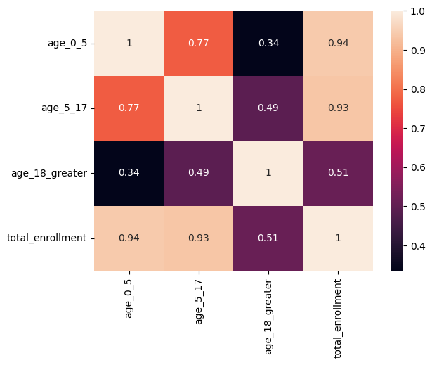

```python
import seaborn as sns
corr = df[['age_0_5','age_5_17','age_18_greater','total_enrollment']].corr()

sns.heatmap(corr, annot=True)
```

# Normalized Comparisons

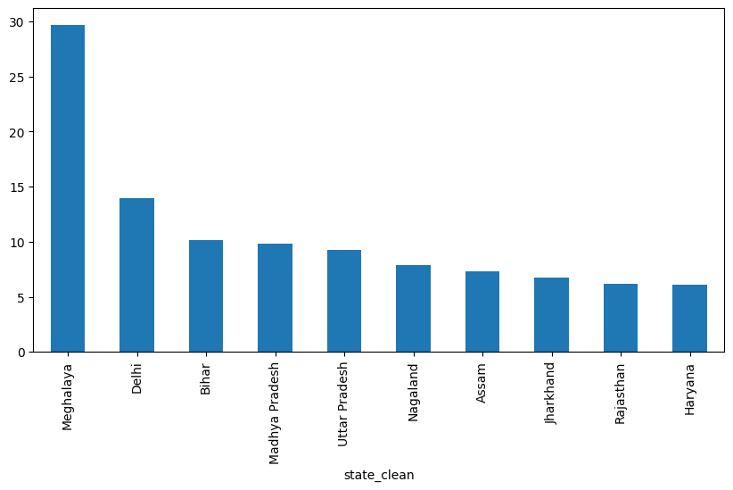

```python
# Per-capita style normalization (proxy)
state_avg = df.groupby('state_clean')['total_enrollment'].mean()

state_avg.sort_values(ascending=False).head(10).plot(
    kind='bar', figsize=(10,5)
)
```

# Bar chart → Top 10 states by total enrollment

Top 10 states account for a significant share of total enrollments, indicating population concentration and higher enrollment activity

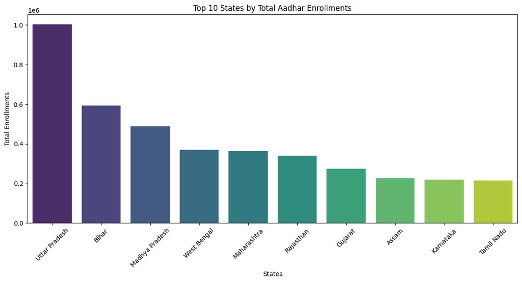

```python
## bar plot for top 10 states
import matplotlib.pyplot as plt
import seaborn as sns
plt.figure(figsize=(14,6))
sns.barplot(
    x=top10_states.index,
    y=top10_states['total_enrollment'],
    palette='viridis'
)
plt.title('Top 10 States by Total Aadhar Enrollments')
plt.xlabel('States')
plt.ylabel('Total Enrollments')
plt.xticks(rotation=45)
plt.show()
```

# Rank Analysis

```python
state_rank = state_summary['total_enrollment'].rank(ascending=False)

state_rank.sort_values().head(10)
```

```
state_clean
Uttar Pradesh      1.0
Bihar              2.0
Madhya Pradesh     3.0
West Bengal        4.0
Maharashtra        5.0
Rajasthan          6.0
Gujarat            7.0
Assam              8.0
Karnataka          9.0
Tamil Nadu        10.0
Name: total_enrollment, dtype: float64
```

# Variability Analysis

🧠 Meaning:  
• High std → inconsistent enrollment  
• Low std → stable system

```python
state_std = df.groupby('state_clean')['total_enrollment'].std()

state_std.sort_values(ascending=False).head(10)
```

```
state_clean
Meghalaya         135.104214
Delhi              77.593888
Uttar Pradesh      56.025312
Bihar              45.115614
Madhya Pradesh     42.377277
Nagaland           41.984775
Haryana            36.049266
Gujarat            34.775802
Assam              33.639722
Manipur            33.200808
Name: total_enrollment, dtype: float64
```

## Age Group Distribution

This analysis examines enrolment contribution of individual age groups.

```python
# Identify age group columns dynamically
age_cols = [c for c in df.columns if c.startswith('age_')]
age_cols
```

```
['age_0_5', 'age_5_17', 'age_18_greater']
```

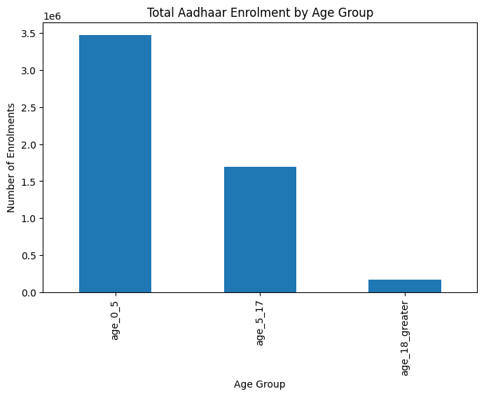

```python
age_totals = df[age_cols].sum().sort_values(ascending=False)

plt.figure(figsize=(8,5))
age_totals.plot(kind='bar')
plt.title("Total Aadhaar Enrolment by Age Group")
plt.xlabel("Age Group")
plt.ylabel("Number of Enrolments")
plt.show()
```

# Children vs Adult Enrollment (Top 10 States)

```python
top10_states['children_enrollment'] = (
    top10_states['age_0_5'] +
    top10_states['age_5_17']
)
```

### 📊 Age Group Enrollment Comparison (Top 10 States)

The bar chart compares enrollment counts between **children** and **adults (18+ age group)** across the top 10 states.

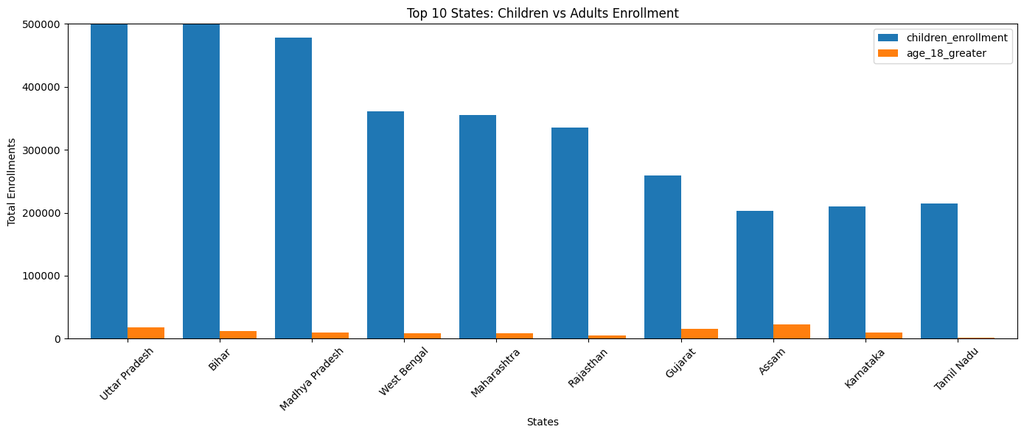

```python
import matplotlib.pyplot as plt

ax = top10_states[['children_enrollment', 'age_18_greater']].plot(
    kind='bar',
    figsize=(14,6),
    width=0.8
)

ax.set_title('Top 10 States: Children vs Adults Enrollment')
ax.set_xlabel('States')
ax.set_ylabel('Total Enrollments')

ax.set_ylim(0, 500000)   # 👈 adjust this value as needed

plt.xticks(rotation=45)
plt.tight_layout()
plt.show()
```

# Age Composition Percentage

States with higher child enrollment percentages may indicate stronger newborn and school-level enrollment outreach.

```python
top10_states['children_percent'] = (
    top10_states['children_enrollment'] /
    top10_states['total_enrollment']
) * 100

top10_states['adult_percent'] = (
    top10_states['age_18_greater'] /
    top10_states['total_enrollment']
) * 100
```

```python
top10_states[['children_percent', 'adult_percent']]
```

| state_clean | children_percent | adult_percent |
| --- | --- | --- |
| Uttar Pradesh | 98.234744 | 1.765256 |
| Bihar | 98.012810 | 1.987190 |
| Madhya Pradesh | 98.057767 | 1.942233 |
| West Bengal | 97.699384 | 2.300616 |
| Maharashtra | 97.770508 | 2.229492 |
| Rajasthan | 98.390151 | 1.609849 |
| Gujarat | 94.159801 | 5.840199 |
| Assam | 89.991525 | 10.008475 |
| Karnataka | 95.429336 | 4.570664 |
| Tamil Nadu | 99.442770 | 0.557230 |

# Plotting Monthly Enrollment trend by age group

```python
# # Monthly enrollment trend
monthly_enrollment = df.groupby('month_name')[[
    'age_0_5', 'age_5_17', 'age_18_greater'
]].sum()
```

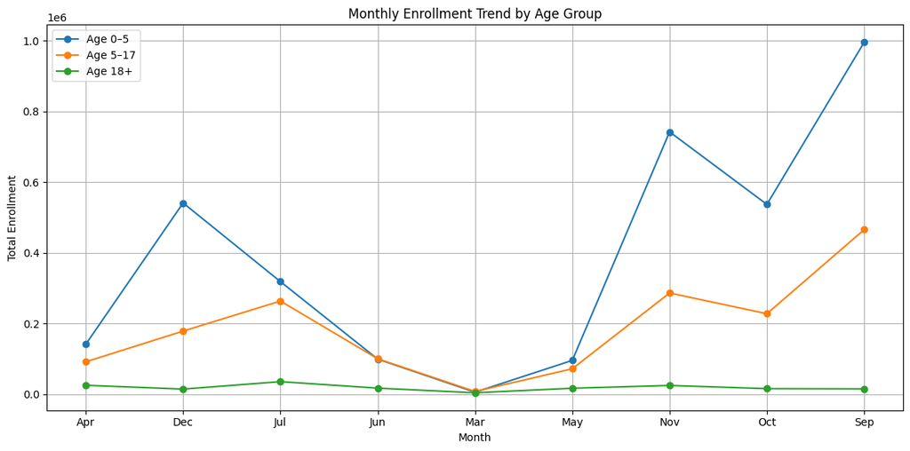

```python
plt.figure(figsize=(12,6))

plt.plot(monthly_enrollment.index,
         monthly_enrollment['age_0_5'],
         marker='o',
         label='Age 0–5')

plt.plot(monthly_enrollment.index,
         monthly_enrollment['age_5_17'],
         marker='o',
         label='Age 5–17')

plt.plot(monthly_enrollment.index,
         monthly_enrollment['age_18_greater'],
         marker='o',
         label='Age 18+')

plt.title('Monthly Enrollment Trend by Age Group')
plt.xlabel('Month')
plt.ylabel('Total Enrollment')
plt.legend()
plt.grid(True)
plt.tight_layout()
plt.show()
```

```python
df.head()
```

|  | date | state | district | pincode | age_0_5 | age_5_17 | age_18_greater | year | month | month_name | state_clean | total_enrollment |
| --- | --- | --- | --- | --- | --- | --- | --- | --- | --- | --- | --- | --- |
| 0 | 2025-03-02 | Meghalaya | East Khasi Hills | 793121 | 11 | 61 | 37 | 2025 | 3 | Mar | Meghalaya | 109 |
| 1 | 2025-03-09 | Karnataka | Bengaluru Urban | 560043 | 14 | 33 | 39 | 2025 | 3 | Mar | Karnataka | 86 |
| 2 | 2025-03-09 | Uttar Pradesh | Kanpur Nagar | 208001 | 29 | 82 | 12 | 2025 | 3 | Mar | Uttar Pradesh | 123 |
| 3 | 2025-03-09 | Uttar Pradesh | Aligarh | 202133 | 62 | 29 | 15 | 2025 | 3 | Mar | Uttar Pradesh | 106 |
| 4 | 2025-03-09 | Karnataka | Bengaluru Urban | 560016 | 14 | 16 | 21 | 2025 | 3 | Mar | Karnataka | 51 |

# State-wise Enrollment Share (%)

[figure not shown]

```python
state_total = df.groupby('state_clean')[['age_0_5','age_5_17','age_18_greater']].sum()
state_total['total'] = state_total.sum(axis=1)

top10 = state_total.sort_values('total', ascending=False).head(10)

(top10['total'] / top10['total'].sum() * 100).plot(
    kind='bar',
    figsize=(12,6)
)

plt.title('Top 10 States: Share of Total Aadhaar Enrollment (%)')
plt.xlabel('State')
plt.ylabel('Percentage Share')
plt.tight_layout()
plt.show()
```

# State-wise Monthly Trend (Top 5 States)

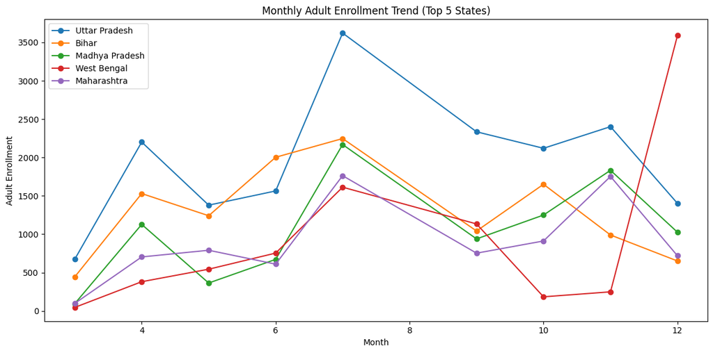

```python
top5_states = top10.index[:5]

monthly_state = df[df['state_clean'].isin(top5_states)].groupby(
    ['state_clean','month']
)['age_18_greater'].sum().reset_index()

plt.figure(figsize=(12,6))

for state in top5_states:
    data = monthly_state[monthly_state['state_clean'] == state]
    plt.plot(data['month'], data['age_18_greater'], marker='o', label=state)

plt.title('Monthly Adult Enrollment Trend (Top 5 States)')
plt.xlabel('Month')
plt.ylabel('Adult Enrollment')
plt.legend()
plt.tight_layout()
plt.show()
```